# AABA 2024 - Wolfe et al. Summary of Analyses

Author

Wolfe CA, Stull KW, Boughner JC

# The Take Home - TLDR Summary

## Extended Summary of Results

1. Multivariate Growth
   - Each extant species has a distinct multivariate pattern of dental development.
   - Homo has a rather less integrated suite of dentition with the strongest relationships between teeth that develop at the same time (i.e., I1, I2, and C). This may suggest that individual teeth are themselves modules apart of a larger biological structure.
   - Pan is overall more ontogentically integrated than Homo. In general, the relationship between developing teeth are stronger.
   - Papio is overall less ontogentically integrated. The model suggests a weak degree of correlation between the developing dentition.
   - Hylobates is intermediate between Papio and Pan. I would argue they are more similar to Homo.
2. Where do hominin species fit in?
- Let’s begin with the presupposition we took from Minden: Naledi (and other species) are on their own biological trajectories. Therefore, let’s assume we cannot just apply extant species generalities to past populations.
- Ok fine - then given what we know about extant species (the models fit here), where may these extinct hominins fit? Can we begin to piece together hominin development as we compare results across extant species?
- Background:
  - Sidron Neanderthal - Rosas et al. say the remains are of a 7-8 year old child. This would be considered late childhood to the juvenile stage in humans.
  - Nariokotome Youth (Ergaster, KNM-WT-1500) - Dean and Smith suggest the remains are most likely that of an juvenile ~8 years old. Although, the skeletal age places it older into adolecence if we assume human skeletal evidence.
  - Naledi 1400 is presumed to be an infant (Cofran et al), Naledi 377 has a unique pattern of development that is not discernible across models.
- Overall, I would argue that no single extant model is able to give us a comprehensive picture. The human model does allow for more patterns that appear to agree with published literature, but this also makes the assumption the human model is best. There is no way to assess “best” in this case. 1) Because we do not know the relationship between true age and life history stages in past populations, and 2) It is likely these past species, like humans, developed their own distinct “species-specific” pattern of development that may be linked to any number of intrinsic and extrinsic factors.

## Rationale

The purpose of this document is to summarize findings associated with the multivariate analysis of tooth mineralization across 4 extant primate species (*Homo, Pan, Papio, Hylobates*). The goals of this work and the resulting AABA presentation are twofold:

1. Provide a species level comparison of [multivariate] dental development across the above mentioned species.
   - This step involves fitting a Bayesian multivariate cumulative probit model to the data and exploring the underlying dependency structure of the data.
     - **Presumption: The underlying dependency structure in the form of a correlation best captures the multivariate changes in tooth development.**
     - **Hypothesis: There will be differences in multivariate relationships between species.**
2. Explore how likely it may (or may not) be that the multivariate information above is an appropriate model to address mineralization in any number of Hominin ancestors.
   - This step treats individual cases (e.g., a published Neanderthal specimen) as a test point and asks the question: *What is the likelihood of this series of dental traits occurring given the model at hand?* This question is obviously age-dependent, so we test the likelihood across ontogeny to see if (and where) it is likely for this series of traits to occur.
     - On it’s face this is akin to the likelihood in an age estimation problem ( $p(trait| \theta, age)$, but this allows us to explore how likely it may or may not be for the data to occur in the fashion we’ve collected and modeled it.
     - This section will require some generalizations on our part. There is no intuitive explanations of (log) likelihood per se, but we will be able to say that given our individual model this is where we see the data falling. Then we can surmise how each individual hominin species fits in.
       - **Presumption: The log likelihood of the test data given the initial modeling parameters is an appropriate metric to determine if the test data (hominin species) fit the underlying data-generating process.**
       - **Hypothesis: The likelihood of observing the multivariate sequence of dental data is age-dependent across each species.**

## Goal 1 - Covariation in Dental Development across Species

[output not shown]

### Homo - Posterior Mean Correlations

**Interpretations:** In general, there is a moderate degree of dependence across the human mandibular dentition. The strongest relationships are between teeth that develop during the same ontogenetic window (*i.e.,* I1, I2, C, and to a lesser degree, M1). In other words, there is a moderate degree of ontogenetic integration present here, but less functional/structural and morphological integration between teeth of the same type (*i.e.,* molars or incisors).

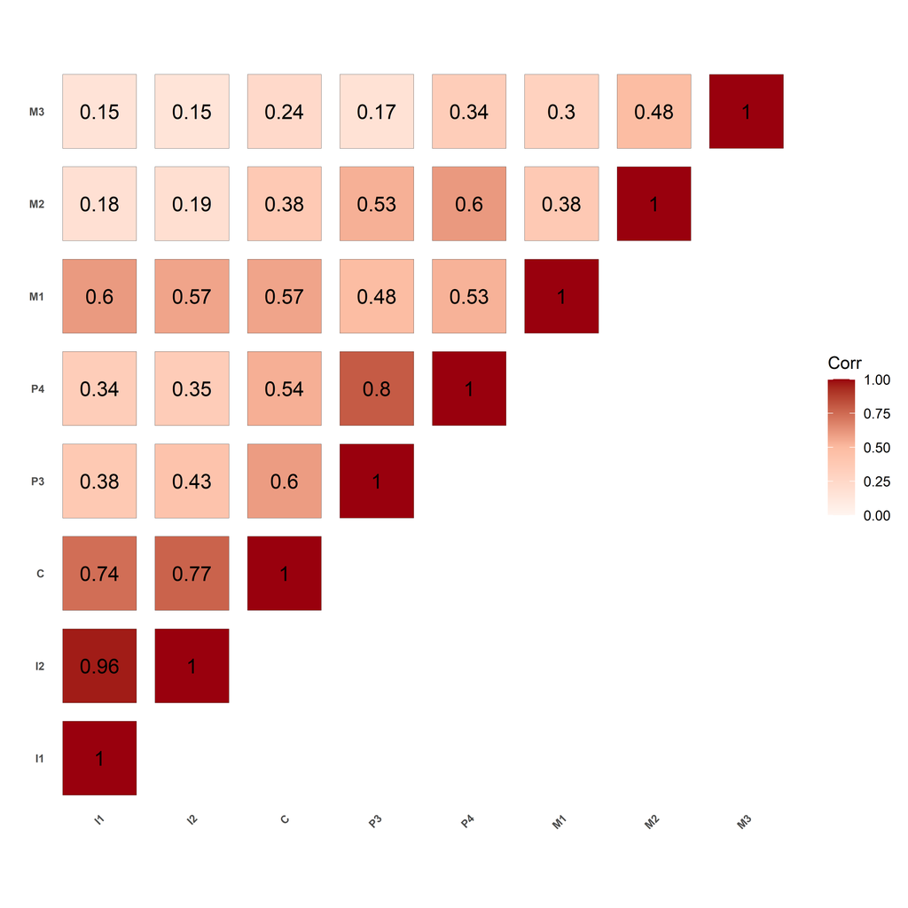

### Pan - Posterior Mean Correlations

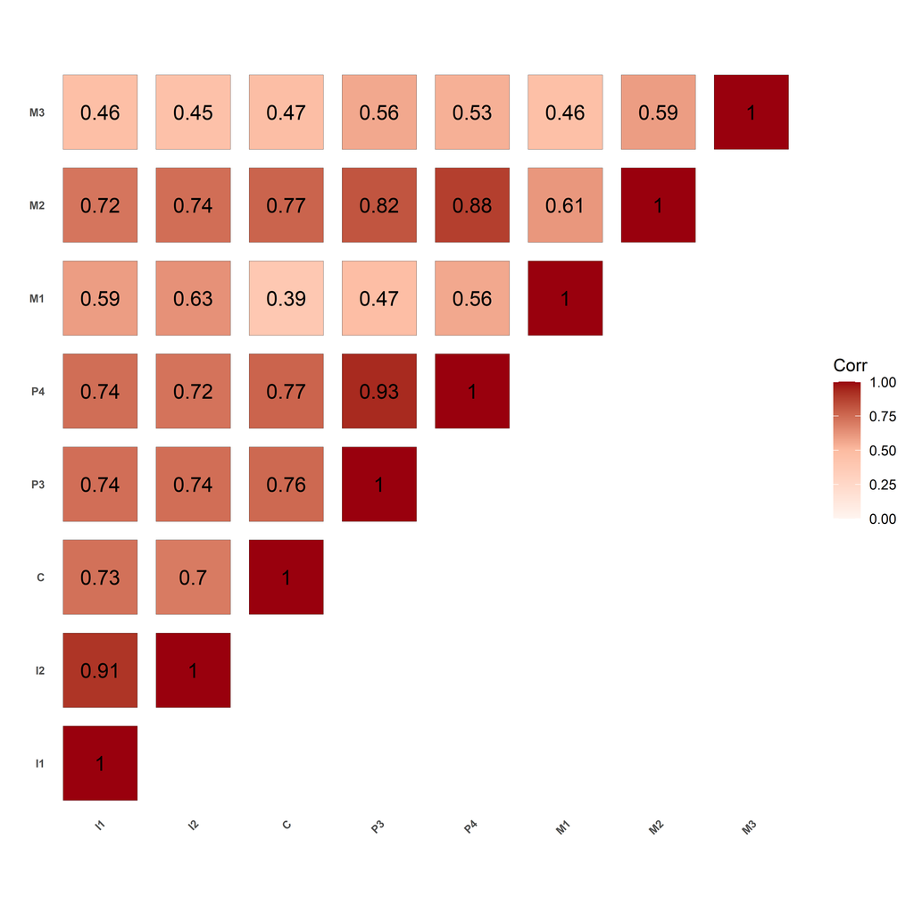

### Papio - Posterior Mean Correlations

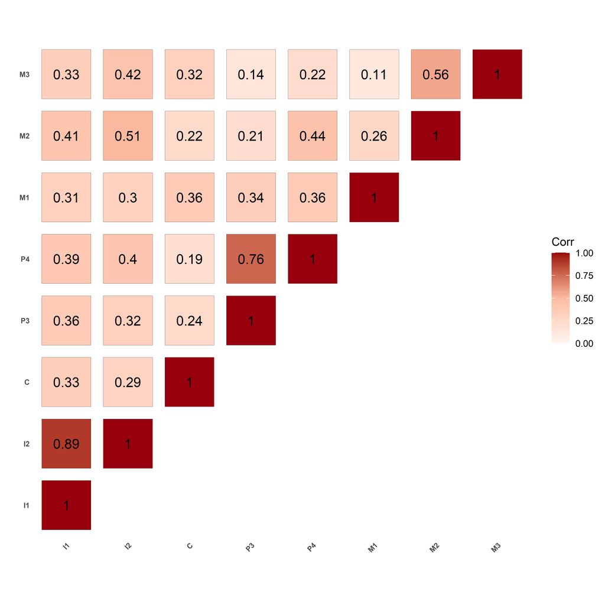

### Hylobates - Posterior Mean Correlations

**Interpretations:** Gibbons fall somewhere between Papio and Pan. Interestingly, they show weakened relationships associated with the canine. I am less familiar with gibbon development, but is this related to a decreased timeframe of development or some other external influence?

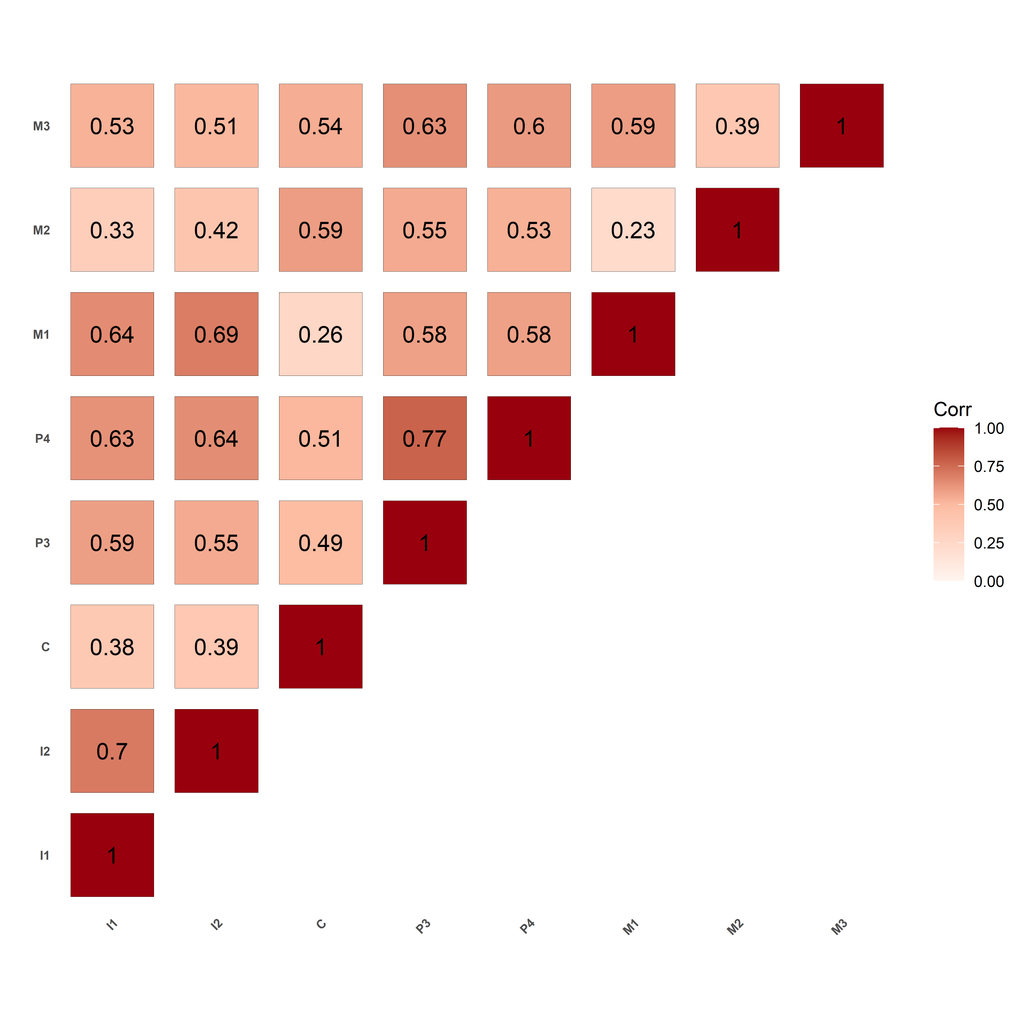

### Approximate Permutation Test

Above we broadly visualize relationships across the dentition. This begs the question, can we test whether we see true differences. In other words: *Are there significant differences in multivariate dental development between species?*

This is not a traditional frequentist p-value or hypothesis test. Here, I use the posterior samples from the Bayesian model in an approximate permutation test where I first find the Kendall’s $\tau$ correlation as a means to test concordance between groups across all sample pairs and then perform a permutation test by re-sampling the data and running the test $N$ number of times. The null hypothesis $H_0$ is no concordance. We can set our own probability here, but lets assume the standard 0.05. I show you raw results first, followed by a summary table at the end.

#### Human to Pan

**Interpretation:** There is a moderate to strong degree of similarity between Pan and Homo.

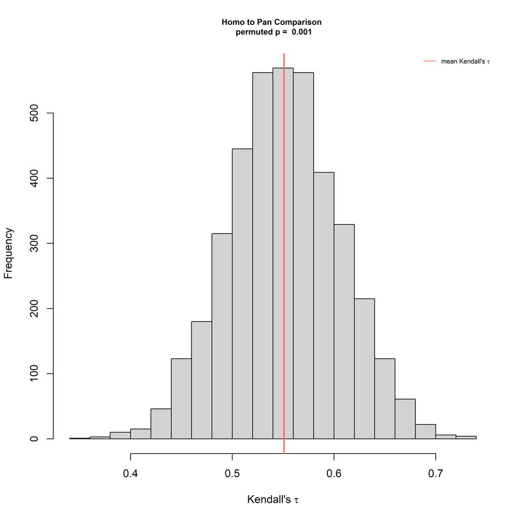

#### Human to Papio

**Interpretation:** There is a moderate to strong degree of concordance between Homo and Papio.

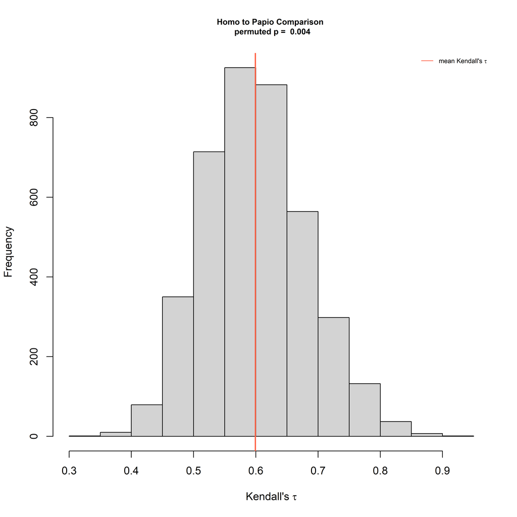

#### Human to Gibbon

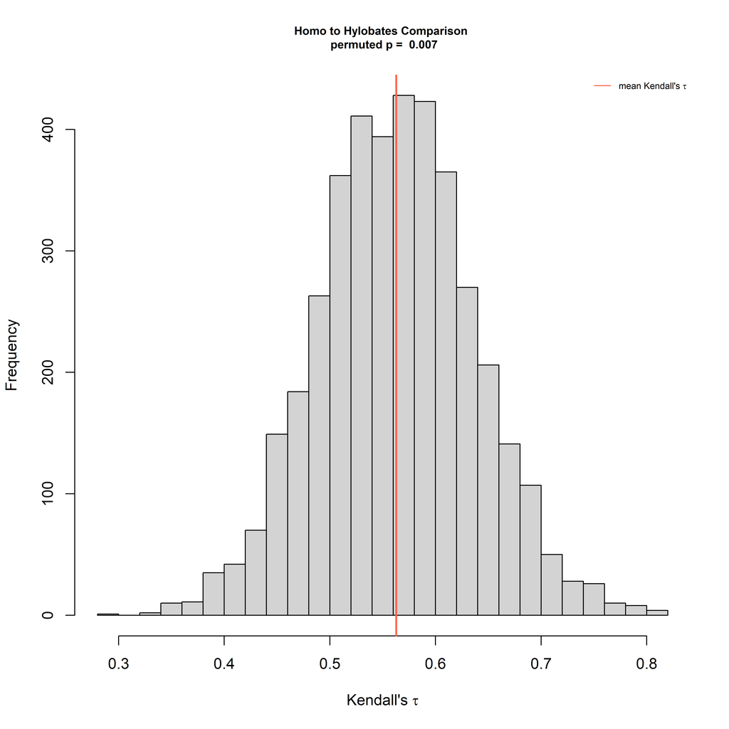

#### Pan Papio

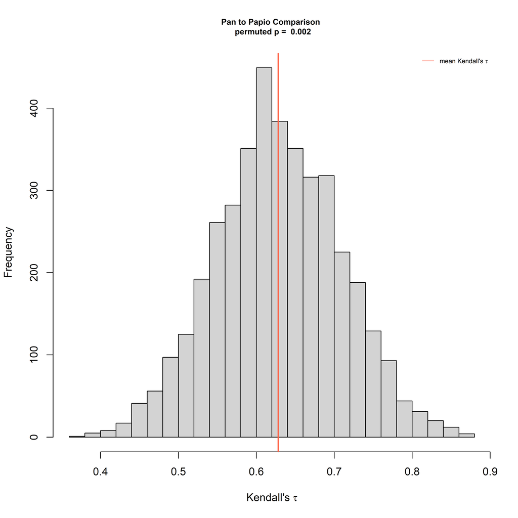

#### Pan to Hylobates

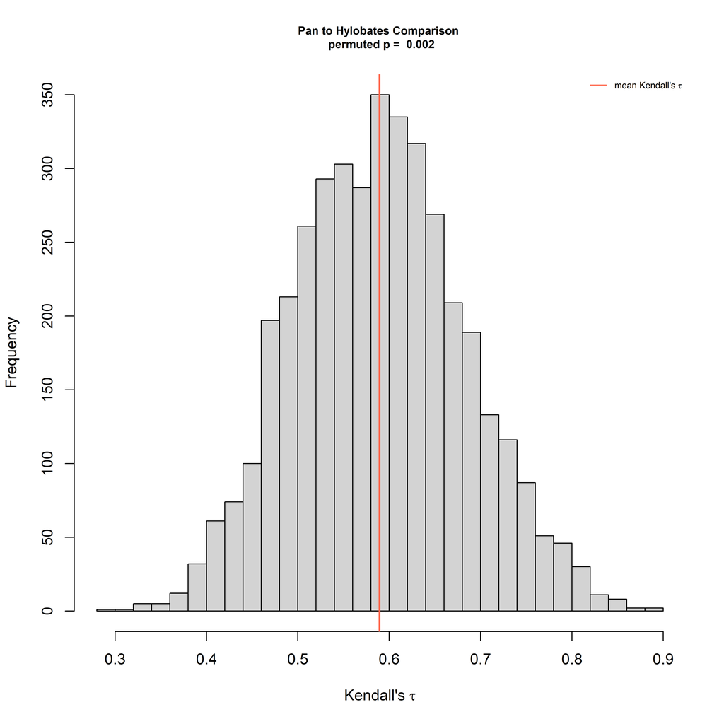

#### Papio to Hylobates

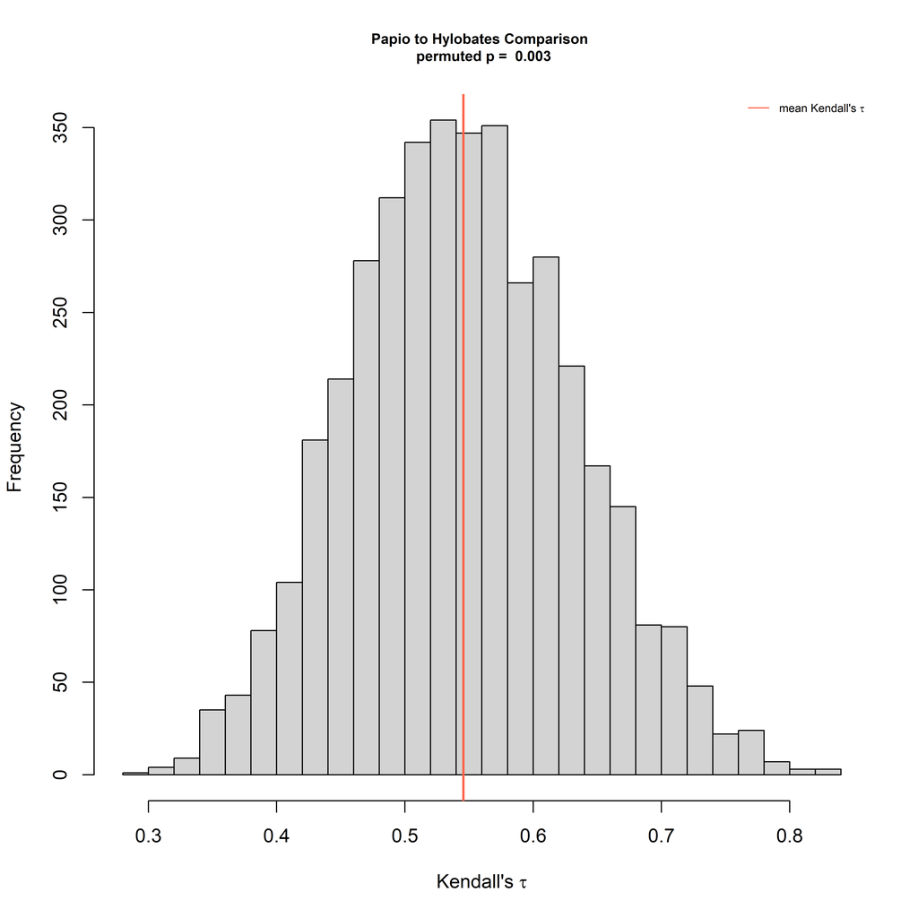

#### Summary

| Comparison | Mean Kendall’s $\tau$ | Perm. P-Value |
| --- | --- | --- |
| Homo-Pan | 0.551 | 0.001 |
| Homo-Papio | 0.599 | 0.004 |
| Homo-Hylobates | 0.563 | 0.007 |
| Pan-Papio | 0.628 | 0.002 |
| Pan-Hylobates | 0.589 | 0.002 |
| Papio-Hylobates | 0.546 | 0.003 |

## Goal 2 - Where do hominin ancestors fit?

Given what we know about developmental and/or ontogenetic integration, let’s assume that hominin species in the past also develop along some multivariate trajectory. Is this trajectory similar to extant species? Here, I treat each individual hominin data point as a test point and ask how likely it is we see the observed hominin dentition across each species given age or age class. The **higher** the likelihood value (close to 0), the better “fitting” the model at that age. This metric is the log posterior predictive density. I test each extant species separately and we can surmise broad patterns from these analyses.

### Homo Model

**Interpretation:** The multivariate dental development pattern in Naledi_1400 is most likely found in a human infant, Naledi_377 in a human juvenile to adolescent, Ergaster in a human juvenile, and the Sidron Neanderthal in a human juvenile.

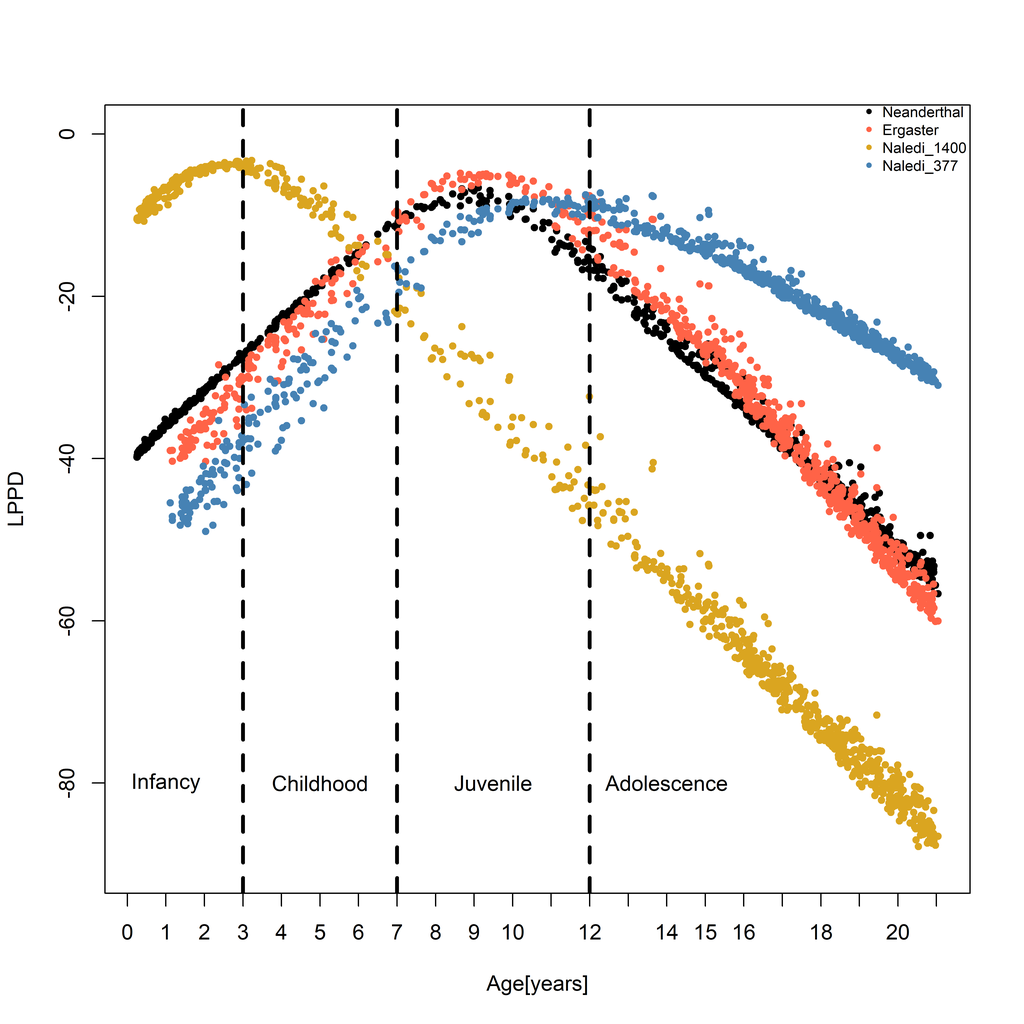

### Pan Model

**Interpretation:** In general, there is no “best performing age” according to the log likelihood across all species of hominin. Naledi_1400 may resemble an infant chimpanzee? Otherwise, there is less clear agreement if we use the Pan data as a model for any of the hominin species. This is admittedly a product of the ordinal nature of the predictor (INF, J1, J2, and ADOL). But there is no way around this.

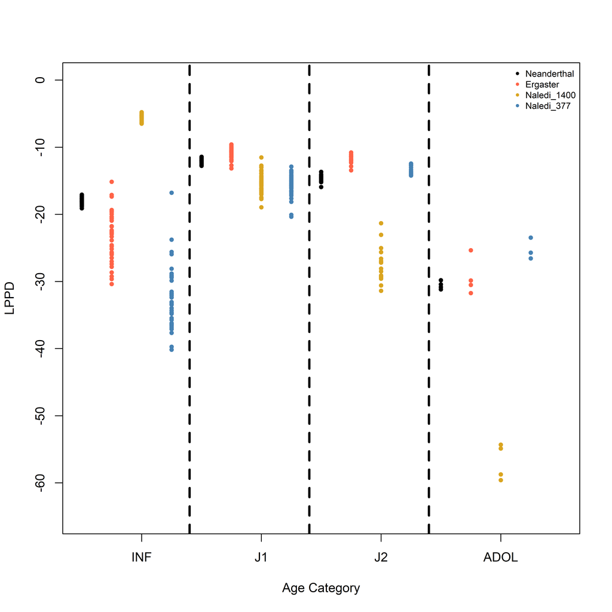

### Papio Model

**Interpretation:** The results here are much like the Pan model above. If we assume hominin dentition follows that of a Papio model, the likelihood of observing the given pattern of dentition is not straightforward. Like above, Naledi_1400 does appear to be younger in origin. But the remainder of the hominin species display dentition that may be found in any number of age categories. This may cloud how we interpret these populations if we use a Papio model.

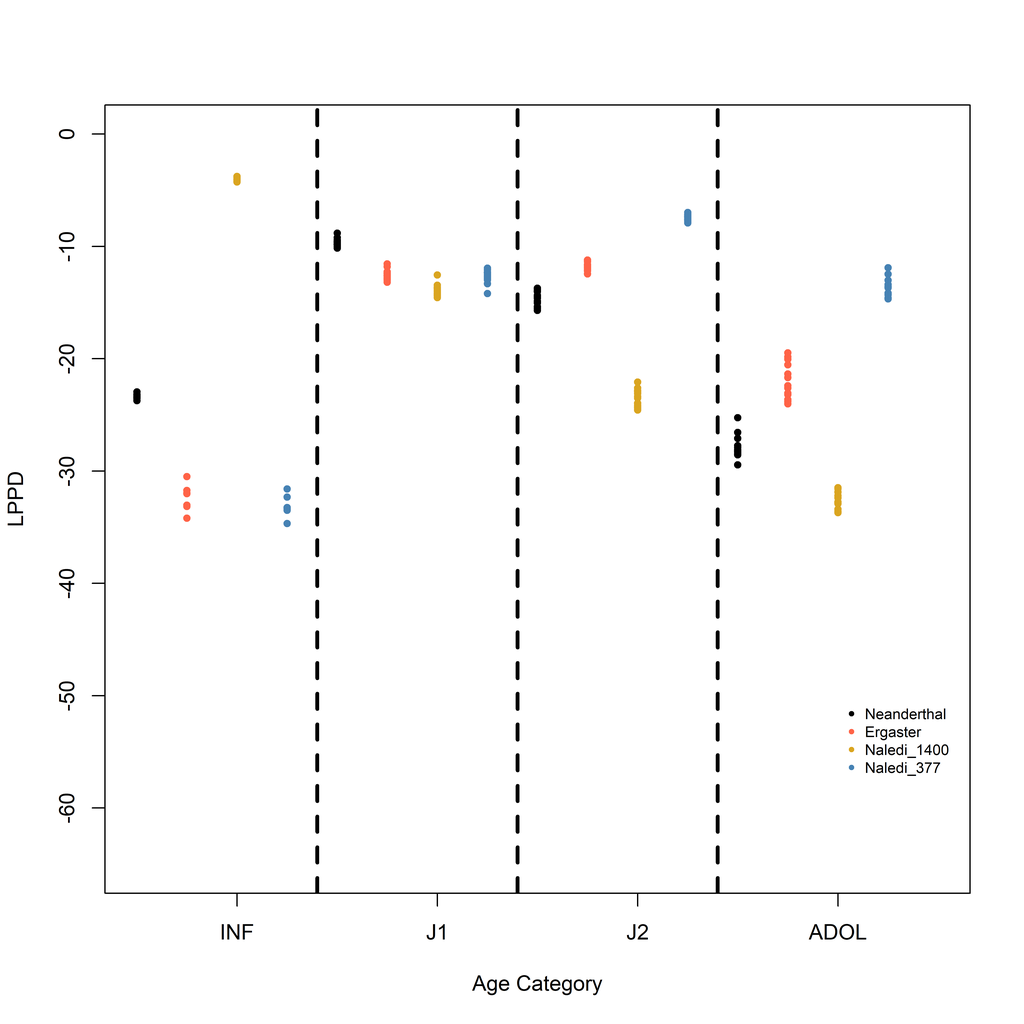

### Hylobates Model

**Interpretation:** Naledi_1400 again shows dentition that is most like an infant gibbon. The remainder of the species are most like either a younger or older juvenile / subadult. Unsurprisingly, no species is likely an adult (“A”).

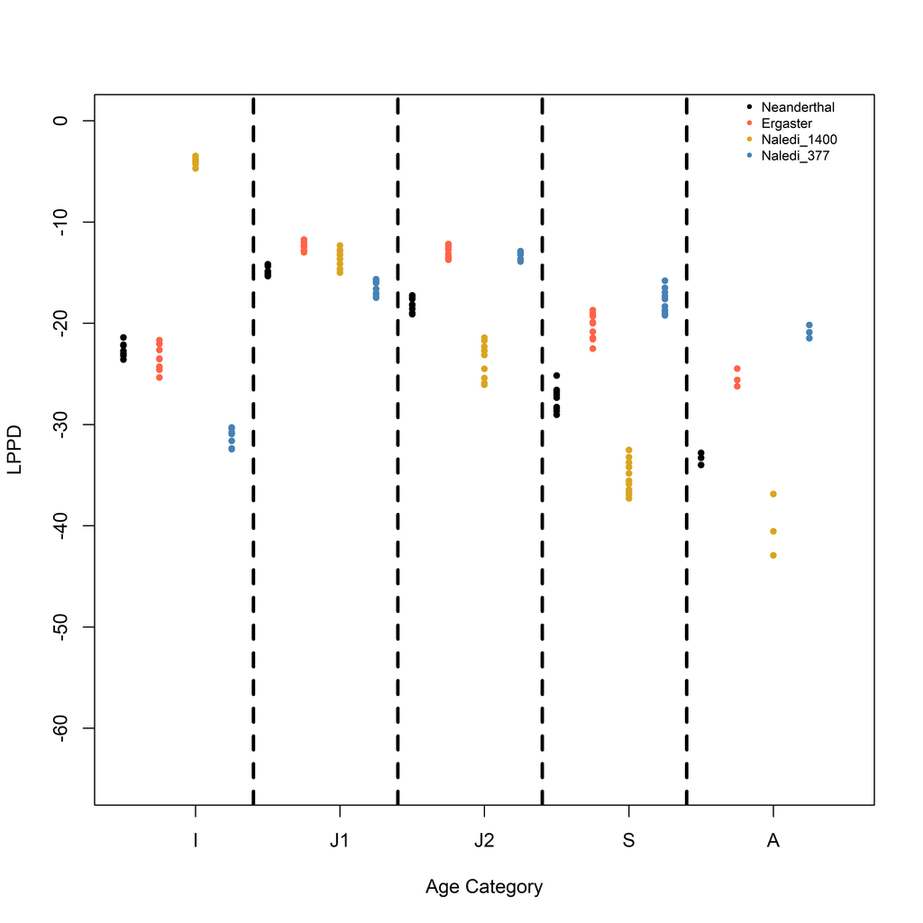